# RNA velocity (velocyto.R) for meox1 and yap1 datasets

Kobayashi et al. 2026

Tyrone Chen

August 05, 2026

# 1 README

RNA velocity (`velocyto.R`) redone on both datasets with intron retention from cellranger.

Two equivalent pipelines are provided for each dataset:

- **Fast path (convenience) - this is what actually runs.** Reads the already-computed velocity estimate objects (`velocyto.<ID>.qs2`, the saved output of a prior `gene.relative.velocity.estimates()` fit) directly, skipping loom loading and re-fitting entirely. It recovers the cell set that went into each object from the object itself (`colnames()` of its internal expression matrix) rather than from loom cell names.
- **Slow path (completeness) - kept below, unmodified, `eval=FALSE`.** The original `meox1_velocyto.R` / `yap1_velocyto.R` logic: computes velocity estimates from scratch, starting from the loom file (`ReadVelocity()` → gene-filtering → `gene.relative.velocity.estimates()`). This is the code that originally produced the `velocyto.<ID>.qs2` objects the fast path reads - kept in full for transparency and as the reference implementation to fall back on (e.g. after regenerating the loom files, or to sanity-check the fast path against a from-scratch refit). Re-fitting `gene.relative.velocity.estimates()` per sample is by far the most expensive step in this document, which is why it isn’t run by default.

Each dataset section below is split into “Slow path (loom-based, for completeness - not run)” and “Fast path (qs2-based, for convenience - this is what actually runs)”.

For each dataset three high-resolution combined+per-sample plots are produced, each with its legend saved separately, intended for custom composition in Illustrator rather than as final figures on their own.

**Note:** `S20200`/`S20201` (meox1) and `S20127`/`S20128` (yap1) are mutant/wildtype sample IDs baked into the source scripts’ filenames - meox1’s `S20200` = mutant, `S20201` = wildtype; yap1’s `S20127` = mutant, `S20128` = wildtype.

## 1.1 Inputs

Fast path (what actually runs) reads precomputed velocity objects from `../../Saki_data/Revision_analysis/queue_plots/`:

- `velocyto.D10051.qs2`, `velocyto.S20200.qs2`, `velocyto.S20201.qs2` (meox1)
- `velocyto.D10025.qs2`, `velocyto.S20127.qs2`, `velocyto.S20128.qs2` (yap1)

## 1.2 Outputs

All under `../output/figure_extended/velocyto/`, one set per dataset (`D10051` = meox1, `D10025` = yap1) and per sample:

- `{meox,yap}_scrna_Level_03_L3_velocyto_introns.<ID>.pdf` (+ `.legend.pdf`)
- `velocyto.<ID>.qs2` (copy of the precomputed object actually used, so downstream users find it in one place regardless of which path produced/supplied it)
- `mini_axis.pdf` (shared UMAP axis stamp, see “Dev utility” section)

## 1.3 Initial setup

```r
libraries <- c(
    "tidyverse",
    "velocyto.R",
    "pagoda2",
    "qs2",
    "Seurat",
    "SeuratWrappers",
    "ggplot2"
)

load_packages <- function(packages) {
    suppressPackageStartupMessages({
        cat(paste("Loading", packages, sep=" "), sep="\n")
        invisible(sapply(
            packages, library, character.only = TRUE, quietly = TRUE
            ))
    })
}
invisible(Sys.setenv(OPENBLAS_NUM_THREADS="1"))
load_packages(libraries)
```

[output not shown]

```r
outfile_dir <- "../output/figure_extended/velocyto/"
dir.create(outfile_dir, recursive = TRUE, showWarnings = FALSE)
precomputed_dir <- "../../Saki_data/Revision_analysis/queue_plots/"

detect_sample_prefixes <- function(loom_cellnames, n_samples) {
    prefixes <- unique(sub(":.*", "", loom_cellnames))
    if (length(prefixes) != n_samples) {
        warning(sprintf("Expected %d samples but found %d prefixes: %s",
                        n_samples, length(prefixes), paste(prefixes, collapse=", ")))
    }
    return(sort(prefixes))  # sort so sample 1 < sample 2
}

# plot parameters shared by both datasets and both pipelines
alpha <- 0.5
cex <<- 0.7
arrow.scale <<- 2
show.grid.flow <<- TRUE
min.grid.cell.mass <<- 1
grid.n <<- 50
arrow.lwd <<- 1
cell.border.alpha <<- 0
n.cores <<- 1

n <- 400
kCells <<- 10
deltaT <<- 3
fit.quantile <<- 0.02
```

## 1.4 Slow path: `run_velocyto_original_loom_based()` (loom-based, kept for completeness)

Identical between the meox1 and yap1 source scripts. Builds the cell-distance matrix, draws the coloured UMAP + legend, filters genes by cluster expression, fits `gene.relative.velocity.estimates()` from loom-derived spliced/unspliced counts, and renders the velocity field over the UMAP embedding. **Defining this function is harmless and kept `eval=TRUE` so it’s visible/checkable in the rendered doc; it is simply never called below** (all the calls that would need it are in the `eval=FALSE` “Slow path” chunks per dataset).

```r
run_velocyto_original_loom_based <- function(
    data_sub, loom_cellnames, ldat, outfile_path, outfile_legend, outfile_obj, label,
    recode_ids=NULL,      # named vector: c("old"="new")
    col_map=NULL,         # named colour vector
    level_order=NULL      # character vector of level order
    ) {                   # -- subset loom assays to matched cells --
    # -- optional recoding --
    if (!is.null(recode_ids)) {
        data_sub$L3_cluster_id <- recode(data_sub$L3_cluster_id, !!!recode_ids)
    }

    # -- optional reordering --
    if (!is.null(level_order)) {
        data_sub$L3_cluster_id <- factor(data_sub$L3_cluster_id, levels=level_order)
    }

    umap_cols <- if (!is.null(col_map)) col_map else NULL

    list_all_assays_filtered <- lapply(names(x=ldat), function(name){
        assay <- ldat[[name]]
        colnames(assay) <- loom_cellnames
        assay <- assay[, intersect(colnames(data_sub), colnames(assay))]
    })
    names(list_all_assays_filtered) <- names(x=ldat)

    emat <- list_all_assays_filtered$spliced
    nmat <- list_all_assays_filtered$unspliced

    emb <- Embeddings(data_sub, reduction="umap")
    cell.dist <- as.dist(1 - armaCor(t(emb)))

    gg <- UMAPPlot(
        data_sub,
        group.by="L3_cluster_id",
        cols=if (!is.null(umap_cols)) umap_cols else waiver()) +
        guides(colour=guide_legend(override.aes=list(shape=16, size=4))) +
        theme_void() +
        theme(
            legend.position=c(1, 1),
            legend.justification=c(1, 1),
            legend.title=element_blank(),
            legend.background=element_blank(),
            legend.key=element_blank()
        )

    colors <- as.list(ggplot_build(gg)$data[[1]]$colour)
    names(colors) <- rownames(emb)

    if (is.null(col_map)) {
        legend_data <- data.frame(
            x=1, y=1,
            L3_cluster_id=factor(unique(data_sub$L3_cluster_id))
        )
    } else {
        legend_data <- data.frame(
            x=1, y=1,
            L3_cluster_id=factor(names(col_map), levels=names(col_map))
        )
    }

    gg_legend <- ggplot(legend_data, aes(x=x, y=y, colour=L3_cluster_id)) +
        geom_point(shape=NA) +
        scale_colour_manual(values=col_map) +
        guides(colour=guide_legend(override.aes=list(shape=16, size=4))) +
        theme_void() +
        theme(
            legend.title=element_blank(),
            legend.background=element_blank(),
            legend.margin=margin(r=200)
        )
    print(gg_legend)
    ggsave(outfile_legend, gg_legend)

    cell_identity <- data_sub$L3_cluster_id

    emat_filtered <- filter.genes.by.cluster.expression(
        emat, cell_identity, min.max.cluster.average=0.1
    )
    nmat_filtered <- filter.genes.by.cluster.expression(
        nmat, cell_identity, min.max.cluster.average=0.05
    )
    cat(sprintf("emat_filtered: %d genes x %d cells\n", nrow(emat_filtered), ncol(emat_filtered)))
    cat(sprintf("nmat_filtered: %d genes x %d cells\n", nrow(nmat_filtered), ncol(nmat_filtered)))

    rvel <- gene.relative.velocity.estimates(
        emat_filtered,
        nmat_filtered,
        deltaT=deltaT,
        kCells=kCells,
        cell.dist=cell.dist,
        fit.quantile=fit.quantile,
        n.cores=n.cores
    )

    velocity_title <- sprintf(
        "Cell Velocity: %s\nfitquantile=%.2f, deltaT=%.1f, kCells=%i, n=%i",
        label, fit.quantile, deltaT, kCells, n
    )
    draw_velocity <- function() {
        par(bty="n")
        show.velocity.on.embedding.cor(
            emb, rvel, n=n, scale='sqrt',
            cell.colors=ac(colors, alpha=alpha),
            cex=cex, arrow.scale=arrow.scale,
            show.grid.flow=show.grid.flow,
            min.grid.cell.mass=min.grid.cell.mass,
            grid.n=grid.n, arrow.lwd=arrow.lwd,
            do.par=F, cell.border.alpha=cell.border.alpha,
            n.cores=n.cores,
            main=velocity_title
        )
    }

    # draw once for the knitted document, once more into the PDF device for the file
    draw_velocity()

    pdf(outfile_path)
    draw_velocity()
    dev.off()

    qs_save(rvel, outfile_obj)
    cat("Saved: ", outfile_obj, "\n")
}
```

## 1.5 Fast path: `run_velocyto_from_precomputed()` (qs2-based, this is what runs)

**Divergence point.** Everything up to and including the UMAP legend/colour setup is unchanged from the slow path - none of it ever touches the loom file, it only ever needs the Seurat object’s own UMAP embedding and cluster identities. The only thing that changes is what happens next: instead of subsetting loom spliced/unspliced counts and calling `gene.relative.velocity.estimates()` to *produce* `rvel`, this version `qs_read()`s an already-fit `rvel` object and uses `colnames()` of its internal expression matrix (`rvel$current`, falling back to `rvel$deltaE`/`rvel$projected` if that field is absent) as the source of truth for which cells to subset the Seurat object to - replacing what `loom_cellnames` did in the slow path. Everything downstream of that (UMAP embedding, colours, drawing, saving) is identical between the two paths.

```r
get_rvel_cells <- function(rvel) {
    for (field in c("current", "deltaE", "projected", "deltaProjected")) {
        if (!is.null(rvel[[field]])) return(colnames(rvel[[field]]))
    }
    stop("Could not determine cell names from precomputed rvel object - inspect its structure with str(rvel, max.level=1)")
}

run_velocyto_from_precomputed <- function(
    data, rvel_path, outfile_path, outfile_legend, outfile_obj, label,
    recode_ids=NULL,      # named vector: c("old"="new")
    col_map=NULL,         # named colour vector
    level_order=NULL      # character vector of level order
    ) {
    # ---- DIVERGENCE POINT: load a previously-fit velocity object instead of computing one from loom counts ----
    rvel <- qs_read(rvel_path)
    rvel_cells <- get_rvel_cells(rvel)

    data_sub <- data[, colnames(data) %in% rvel_cells]
    cat(sprintf("Precomputed rvel has %d cells; %d found in Seurat object\n",
                length(rvel_cells), ncol(data_sub)))
    # ---- end divergence point; everything below matches run_velocyto_original_loom_based() ----

    # -- optional recoding --
    if (!is.null(recode_ids)) {
        data_sub$L3_cluster_id <- recode(data_sub$L3_cluster_id, !!!recode_ids)
    }

    # -- optional reordering --
    if (!is.null(level_order)) {
        data_sub$L3_cluster_id <- factor(data_sub$L3_cluster_id, levels=level_order)
    }

    umap_cols <- if (!is.null(col_map)) col_map else NULL

    emb <- Embeddings(data_sub, reduction="umap")

    gg <- UMAPPlot(
        data_sub,
        group.by="L3_cluster_id",
        cols=if (!is.null(umap_cols)) umap_cols else waiver()) +
        guides(colour=guide_legend(override.aes=list(shape=16, size=4))) +
        theme_void() +
        theme(
            legend.position=c(1, 1),
            legend.justification=c(1, 1),
            legend.title=element_blank(),
            legend.background=element_blank(),
            legend.key=element_blank()
        )

    colors <- as.list(ggplot_build(gg)$data[[1]]$colour)
    names(colors) <- rownames(emb)

    if (is.null(col_map)) {
        legend_data <- data.frame(
            x=1, y=1,
            L3_cluster_id=factor(unique(data_sub$L3_cluster_id))
        )
    } else {
        legend_data <- data.frame(
            x=1, y=1,
            L3_cluster_id=factor(names(col_map), levels=names(col_map))
        )
    }

    gg_legend <- ggplot(legend_data, aes(x=x, y=y, colour=L3_cluster_id)) +
        geom_point(shape=NA) +
        scale_colour_manual(values=col_map) +
        guides(colour=guide_legend(override.aes=list(shape=16, size=4))) +
        theme_void() +
        theme(
            legend.title=element_blank(),
            legend.background=element_blank(),
            legend.margin=margin(r=200)
        )
    print(gg_legend)
    ggsave(outfile_legend, gg_legend)

    velocity_title <- sprintf(
        "Cell Velocity: %s\nfitquantile=%.2f, deltaT=%.1f, kCells=%i, n=%i",
        label, fit.quantile, deltaT, kCells, n
    )
    draw_velocity <- function() {
        par(bty="n")
        show.velocity.on.embedding.cor(
            emb, rvel, n=n, scale='sqrt',
            cell.colors=ac(colors, alpha=alpha),
            cex=cex, arrow.scale=arrow.scale,
            show.grid.flow=show.grid.flow,
            min.grid.cell.mass=min.grid.cell.mass,
            grid.n=grid.n, arrow.lwd=arrow.lwd,
            do.par=F, cell.border.alpha=cell.border.alpha,
            n.cores=n.cores,
            main=velocity_title
        )
    }

    # draw once for the knitted document, once more into the PDF device for the file
    draw_velocity()

    pdf(outfile_path)
    draw_velocity()
    dev.off()

    # re-save alongside the other outputs, so downstream users find it in one place
    # regardless of whether it was freshly computed or read in precomputed
    qs_save(rvel, outfile_obj)
    cat("Saved: ", outfile_obj, "\n")
}
```

## 1.6 meox1 (D10051)

Source: `meox1_velocyto.R`. `S20200` = meox1 mutant, `S20201` = wildtype.

### 1.6.1 Slow path (loom-based, for completeness - not run)

```r
infile_path <- "../../Saki_data/paper/D10051_meox1_dataset_Level_03_annotated.qs2"
infile_loom <- "../../Saki_data/Revision_analysis/Dataset_10051_meox1_scRNAseq.loom"

outfile_path_D10051 <- paste(outfile_dir, "meox_scrna_Level_03_L3_velocyto_introns.D10051.pdf", sep="/")
outfile_legend_D10051 <- paste(outfile_dir, "meox_scrna_Level_03_L3_velocyto_introns.D10051.legend.pdf", sep="/")
outfile_obj_D10051 <- paste(outfile_dir, "velocyto.D10051.qs2", sep="/")

outfile_path_S20200 <- paste(outfile_dir, "meox_scrna_Level_03_L3_velocyto_introns.S20200.pdf", sep="/")
outfile_legend_S20200 <- paste(outfile_dir, "meox_scrna_Level_03_L3_velocyto_introns.S20200.legend.pdf", sep="/")
outfile_obj_S20200 <- paste(outfile_dir, "velocyto.S20200.qs2", sep="/")

outfile_path_S20201 <- paste(outfile_dir, "meox_scrna_Level_03_L3_velocyto_introns.S20201.pdf", sep="/")
outfile_legend_S20201 <- paste(outfile_dir, "meox_scrna_Level_03_L3_velocyto_introns.S20201.legend.pdf", sep="/")
outfile_obj_S20201 <- paste(outfile_dir, "velocyto.S20201.qs2", sep="/")

data <- qs_read(infile_path)
table(data@meta.data$L3_cluster_id)
group.by <- "L3_cluster_id"
ldat <- ReadVelocity(infile_loom)

# -- cell name matching --
loom_cellnames <- colnames(ldat$spliced)
sample_names <- detect_sample_prefixes(loom_cellnames, n_samples = 2)
cat("Detected prefixes:", paste(sample_names, collapse=", "), "\n")

for (i in 1:length(sample_names)) {
    current_name <- sprintf("%s:(.*)x", sample_names[i])
    loom_cellnames <- gsub(current_name, sprintf("\\1-1_%i", i), loom_cellnames)
}

# -- subset Seurat to cells present in loom --
n_missing <- sum(!colnames(data) %in% loom_cellnames)
if (n_missing > 0) {
    cat(sprintf("Note: %d / %d Seurat cells missing from loom, subsetting\n",
                n_missing, ncol(data)))
}
data_sub <- data[, colnames(data) %in% loom_cellnames]
cat(sprintf("Proceeding with %d cells\n", ncol(data_sub)))

data_S20200 <- data_sub[, grepl("_1$", colnames(data_sub))]
data_S20201 <- data_sub[, grepl("_2$", colnames(data_sub))]
loom_S20200 <- loom_cellnames[grepl("_1$", loom_cellnames)]
loom_S20201 <- loom_cellnames[grepl("_2$", loom_cellnames)]

recode_D10051 <- c(
    "mVEC_01"="msVEC",
    "LEC_01"="LEC",
    "hmVEC_01"="hmsVEC",
    "pre_muLEC_01"="pre_muLEC"
)
order_D10051 <- c(
    "LEC",
    "pre_muLEC",
    "hmsVEC",
    "msVEC"
)
col_map_D10051 <- c(
    "LEC"       = "#41ae76",
    "pre_muLEC" = "#fec44f",
    "hmsVEC"    = "#9ecae1",
    "msVEC"     = "#6baed6"
)
```

```r
# combined - all samples, with full colour map and ordering
run_velocyto_original_loom_based(
    data_sub=data_sub,
    loom_cellnames=loom_cellnames,
    ldat=ldat,
    outfile_path=outfile_path_D10051,
    outfile_legend=outfile_legend_D10051,
    outfile_obj=outfile_obj_D10051,
    label="D10051",
    recode_ids=recode_D10051,
    col_map=col_map_D10051,
    level_order=order_D10051
)

run_velocyto_original_loom_based(
    data_sub=data_S20200,
    loom_cellnames=loom_cellnames,
    ldat=ldat,
    outfile_path=outfile_path_S20200,
    outfile_legend=outfile_legend_S20200,
    outfile_obj=outfile_obj_S20200,
    label="S20200_MUT",
    recode_ids=recode_D10051,
    col_map=col_map_D10051,
    level_order=order_D10051
)

run_velocyto_original_loom_based(
    data_sub=data_S20201,
    loom_cellnames=loom_cellnames,
    ldat=ldat,
    outfile_path=outfile_path_S20201,
    outfile_legend=outfile_legend_S20201,
    outfile_obj=outfile_obj_S20201,
    label="S20201_WT",
    recode_ids=recode_D10051,
    col_map=col_map_D10051,
    level_order=order_D10051
)
```

### 1.6.2 Fast path (qs2-based, for convenience - this is what actually runs)

```r
infile_path <- "../../Saki_data/paper/D10051_meox1_dataset_Level_03_annotated.qs2"

outfile_path_D10051 <- paste(outfile_dir, "meox_scrna_Level_03_L3_velocyto_introns.D10051.pdf", sep="/")
outfile_legend_D10051 <- paste(outfile_dir, "meox_scrna_Level_03_L3_velocyto_introns.D10051.legend.pdf", sep="/")
outfile_obj_D10051 <- paste(outfile_dir, "velocyto.D10051.qs2", sep="/")
rvel_path_D10051 <- paste0(precomputed_dir, "velocyto.D10051.qs2")

outfile_path_S20200 <- paste(outfile_dir, "meox_scrna_Level_03_L3_velocyto_introns.S20200.pdf", sep="/")
outfile_legend_S20200 <- paste(outfile_dir, "meox_scrna_Level_03_L3_velocyto_introns.S20200.legend.pdf", sep="/")
outfile_obj_S20200 <- paste(outfile_dir, "velocyto.S20200.qs2", sep="/")
rvel_path_S20200 <- paste0(precomputed_dir, "velocyto.S20200.qs2")

outfile_path_S20201 <- paste(outfile_dir, "meox_scrna_Level_03_L3_velocyto_introns.S20201.pdf", sep="/")
outfile_legend_S20201 <- paste(outfile_dir, "meox_scrna_Level_03_L3_velocyto_introns.S20201.legend.pdf", sep="/")
outfile_obj_S20201 <- paste(outfile_dir, "velocyto.S20201.qs2", sep="/")
rvel_path_S20201 <- paste0(precomputed_dir, "velocyto.S20201.qs2")

data <- qs_read(infile_path)
table(data@meta.data$L3_cluster_id)
```

```
##
##      mVEC_01       LEC_01     hmVEC_01 pre_muLEC_01
##         1384          516          505          170
```

```r
recode_D10051 <- c(
    "mVEC_01"="msVEC",
    "LEC_01"="LEC",
    "hmVEC_01"="hmsVEC",
    "pre_muLEC_01"="pre_muLEC"
)
order_D10051 <- c(
    "LEC",
    "pre_muLEC",
    "hmsVEC",
    "msVEC"
)
col_map_D10051 <- c(
    "LEC"       = "#41ae76",
    "pre_muLEC" = "#fec44f",
    "hmsVEC"    = "#9ecae1",
    "msVEC"     = "#6baed6"
)
```

```r
run_velocyto_from_precomputed(
    data=data,
    rvel_path=rvel_path_D10051,
    outfile_path=outfile_path_D10051,
    outfile_legend=outfile_legend_D10051,
    outfile_obj=outfile_obj_D10051,
    label="D10051",
    recode_ids=recode_D10051,
    col_map=col_map_D10051,
    level_order=order_D10051
)
```

```
## Precomputed rvel has 2575 cells; 2575 found in Seurat object
```

```
## delta projections ... sqrt knn ... transition probs ... done
## calculating arrows ... done
## grid estimates ... grid.sd= 0.1731681  min.arrow.size= 0.003463362  max.grid.arrow.length= 0.03284935  done
```

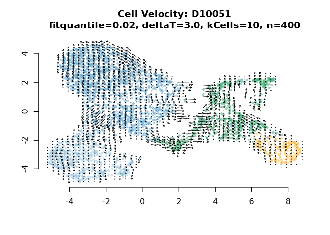

```
## delta projections ... sqrt knn ... transition probs ... done
## calculating arrows ... done
## grid estimates ... grid.sd= 0.1731681  min.arrow.size= 0.003463362  max.grid.arrow.length= 0.03866626  done
## Saved:  ../output/figure_extended/velocyto//velocyto.D10051.qs2
```

```r
run_velocyto_from_precomputed(
    data=data,
    rvel_path=rvel_path_S20200,
    outfile_path=outfile_path_S20200,
    outfile_legend=outfile_legend_S20200,
    outfile_obj=outfile_obj_S20200,
    label="S20200_MUT",
    recode_ids=recode_D10051,
    col_map=col_map_D10051,
    level_order=order_D10051
)
```

```
## Precomputed rvel has 1288 cells; 1288 found in Seurat object
```

```
## delta projections ... sqrt knn ... transition probs ... done
## calculating arrows ... done
## grid estimates ... grid.sd= 0.1719926  min.arrow.size= 0.003439851  max.grid.arrow.length= 0.03284935  done
```

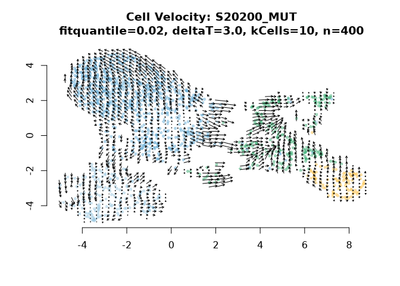

```
## delta projections ... sqrt knn ... transition probs ... done
## calculating arrows ... done
## grid estimates ... grid.sd= 0.1719926  min.arrow.size= 0.003439851  max.grid.arrow.length= 0.03866626  done
## Saved:  ../output/figure_extended/velocyto//velocyto.S20200.qs2
```

```r
run_velocyto_from_precomputed(
    data=data,
    rvel_path=rvel_path_S20201,
    outfile_path=outfile_path_S20201,
    outfile_legend=outfile_legend_S20201,
    outfile_obj=outfile_obj_S20201,
    label="S20201_WT",
    recode_ids=recode_D10051,
    col_map=col_map_D10051,
    level_order=order_D10051
)
```

```
## Precomputed rvel has 1287 cells; 1287 found in Seurat object
```

```
## delta projections ... sqrt knn ... transition probs ... done
## calculating arrows ... done
## grid estimates ... grid.sd= 0.1716293  min.arrow.size= 0.003432586  max.grid.arrow.length= 0.03284935  done
```

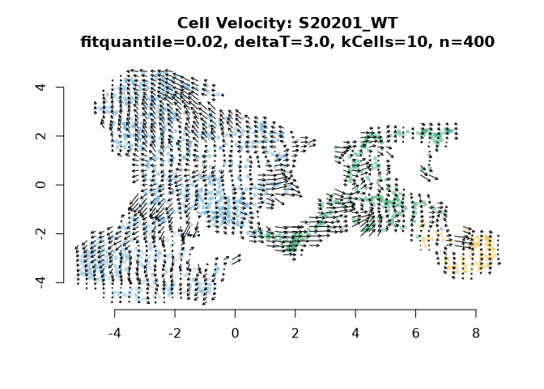

```
## delta projections ... sqrt knn ... transition probs ... done
## calculating arrows ... done
## grid estimates ... grid.sd= 0.1716293  min.arrow.size= 0.003432586  max.grid.arrow.length= 0.03866626  done
## Saved:  ../output/figure_extended/velocyto//velocyto.S20201.qs2
```

## 1.7 yap1 (D10025)

Source: `yap1_velocyto.R`.

### 1.7.1 Slow path (loom-based, for completeness - not run)

```r
infile_path_yap <- "../../Saki_data/paper/D10025_yap1_dataset_Level_03_annotated.qs2"
infile_loom_yap <- "../../Saki_data/Revision_analysis/Dataset_10025_Yap_scRNAseq.20260311.intron.loom"

outfile_path_D10025 <- paste(outfile_dir, "yap_scrna_Level_03_L3_velocyto_introns.D10025.pdf", sep="/")
outfile_legend_D10025 <- paste(outfile_dir, "yap_scrna_Level_03_L3_velocyto_introns.D10025.legend.pdf", sep="/")
outfile_obj_D10025 <- paste(outfile_dir, "velocyto.D10025.qs2", sep="/")

outfile_path_S20127 <- paste(outfile_dir, "yap_scrna_Level_03_L3_velocyto_introns.S20127.pdf", sep="/")
outfile_legend_S20127 <- paste(outfile_dir, "yap_scrna_Level_03_L3_velocyto_introns.S20127.legend.pdf", sep="/")
outfile_obj_S20127 <- paste(outfile_dir, "velocyto.S20127.qs2", sep="/")

outfile_path_S20128 <- paste(outfile_dir, "yap_scrna_Level_03_L3_velocyto_introns.S20128.pdf", sep="/")
outfile_legend_S20128 <- paste(outfile_dir, "yap_scrna_Level_03_L3_velocyto_introns.S20128.legend.pdf", sep="/")
outfile_obj_S20128 <- paste(outfile_dir, "velocyto.S20128.qs2", sep="/")

data_yap <- qs_read(infile_path_yap)
table(data_yap@meta.data$L3_cluster_id)
ldat_yap <- ReadVelocity(infile_loom_yap)

# -- cell name matching --
loom_cellnames_yap <- colnames(ldat_yap$spliced)
sample_names_yap <- detect_sample_prefixes(loom_cellnames_yap, n_samples = 2)
cat("Detected prefixes:", paste(sample_names_yap, collapse=", "), "\n")

for (i in 1:length(sample_names_yap)) {
    current_name <- sprintf("%s:(.*)x", sample_names_yap[i])
    loom_cellnames_yap <- gsub(current_name, sprintf("\\1-1_%i", i), loom_cellnames_yap)
}

# -- subset Seurat to cells present in loom --
n_missing_yap <- sum(!colnames(data_yap) %in% loom_cellnames_yap)
if (n_missing_yap > 0) {
    cat(sprintf("Note: %d / %d Seurat cells missing from loom, subsetting\n",
                n_missing_yap, ncol(data_yap)))
}
data_sub_yap <- data_yap[, colnames(data_yap) %in% loom_cellnames_yap]
cat(sprintf("Proceeding with %d cells\n", ncol(data_sub_yap)))

data_S20127 <- data_sub_yap[, grepl("_1$", colnames(data_sub_yap))]
data_S20128 <- data_sub_yap[, grepl("_2$", colnames(data_sub_yap))]
loom_S20127 <- loom_cellnames_yap[grepl("_1$", loom_cellnames_yap)]
loom_S20128 <- loom_cellnames_yap[grepl("_2$", loom_cellnames_yap)]

recode_D10025 <- c(
    "LEC_01"="LEC",
    "preLEC_01"="preLEC",
    "hmVEC_01"="hmsVEC",
    "mVEC_01"="msVEC",
    "cVEC_01"="cvpVEC",
    "iVEC_01"="IL_VEC"
)
order_D10025 <- c(
    "LEC",
    "preLEC",
    "hmsVEC",
    "msVEC",
    "cvpVEC",
    "IL_VEC"
)
col_map_D10025 <- c(
    "LEC"     = "#41ae76",
    "preLEC"  = "#a1d99b",
    "hmsVEC"  = "#9ecae1",
    "msVEC"   = "#6baed6",
    "cvpVEC"  = "#4292c6",
    "IL_VEC"  = "#084594"
)
```

```r
# combined - all samples, with full colour map and ordering
run_velocyto_original_loom_based(
    data_sub=data_sub_yap,
    loom_cellnames=loom_cellnames_yap,
    ldat=ldat_yap,
    outfile_path=outfile_path_D10025,
    outfile_legend=outfile_legend_D10025,
    outfile_obj=outfile_obj_D10025,
    label="D10025",
    recode_ids=recode_D10025,
    col_map=col_map_D10025,
    level_order=order_D10025
)

run_velocyto_original_loom_based(
    data_sub=data_S20127,
    loom_cellnames=loom_cellnames_yap,
    ldat=ldat_yap,
    outfile_path=outfile_path_S20127,
    outfile_legend=outfile_legend_S20127,
    outfile_obj=outfile_obj_S20127,
    label="S20127_MUT",
    recode_ids=recode_D10025,
    col_map=col_map_D10025,
    level_order=order_D10025
)

run_velocyto_original_loom_based(
    data_sub=data_S20128,
    loom_cellnames=loom_cellnames_yap,
    ldat=ldat_yap,
    outfile_path=outfile_path_S20128,
    outfile_legend=outfile_legend_S20128,
    outfile_obj=outfile_obj_S20128,
    label="S20128_WT",
    recode_ids=recode_D10025,
    col_map=col_map_D10025,
    level_order=order_D10025
)
```

### 1.7.2 Fast path (qs2-based, for convenience - this is what actually runs)

```r
infile_path_yap <- "../../Saki_data/paper/D10025_yap1_dataset_Level_03_annotated.qs2"

outfile_path_D10025 <- paste(outfile_dir, "yap_scrna_Level_03_L3_velocyto_introns.D10025.pdf", sep="/")
outfile_legend_D10025 <- paste(outfile_dir, "yap_scrna_Level_03_L3_velocyto_introns.D10025.legend.pdf", sep="/")
outfile_obj_D10025 <- paste(outfile_dir, "velocyto.D10025.qs2", sep="/")
rvel_path_D10025 <- paste0(precomputed_dir, "velocyto.D10025.qs2")

outfile_path_S20127 <- paste(outfile_dir, "yap_scrna_Level_03_L3_velocyto_introns.S20127.pdf", sep="/")
outfile_legend_S20127 <- paste(outfile_dir, "yap_scrna_Level_03_L3_velocyto_introns.S20127.legend.pdf", sep="/")
outfile_obj_S20127 <- paste(outfile_dir, "velocyto.S20127.qs2", sep="/")
rvel_path_S20127 <- paste0(precomputed_dir, "velocyto.S20127.qs2")

outfile_path_S20128 <- paste(outfile_dir, "yap_scrna_Level_03_L3_velocyto_introns.S20128.pdf", sep="/")
outfile_legend_S20128 <- paste(outfile_dir, "yap_scrna_Level_03_L3_velocyto_introns.S20128.legend.pdf", sep="/")
outfile_obj_S20128 <- paste(outfile_dir, "velocyto.S20128.qs2", sep="/")
rvel_path_S20128 <- paste0(precomputed_dir, "velocyto.S20128.qs2")

data_yap <- qs_read(infile_path_yap)
table(data_yap@meta.data$L3_cluster_id)
```

```
##
## preLEC_01   mVEC_01  hmVEC_01   cVEC_01    LEC_01   iVEC_01
##      2461      1385      1209       763       656        83
```

```r
recode_D10025 <- c(
    "LEC_01"="LEC",
    "preLEC_01"="preLEC",
    "hmVEC_01"="hmsVEC",
    "mVEC_01"="msVEC",
    "cVEC_01"="cvpVEC",
    "iVEC_01"="IL_VEC"
)
order_D10025 <- c(
    "LEC",
    "preLEC",
    "hmsVEC",
    "msVEC",
    "cvpVEC",
    "IL_VEC"
)
col_map_D10025 <- c(
    "LEC"     = "#41ae76",
    "preLEC"  = "#a1d99b",
    "hmsVEC"  = "#9ecae1",
    "msVEC"   = "#6baed6",
    "cvpVEC"  = "#4292c6",
    "IL_VEC"  = "#084594"
)
```

```r
run_velocyto_from_precomputed(
    data=data_yap,
    rvel_path=rvel_path_D10025,
    outfile_path=outfile_path_D10025,
    outfile_legend=outfile_legend_D10025,
    outfile_obj=outfile_obj_D10025,
    label="D10025",
    recode_ids=recode_D10025,
    col_map=col_map_D10025,
    level_order=order_D10025
)
```

```
## Precomputed rvel has 6459 cells; 6459 found in Seurat object
```

```
## delta projections ... sqrt knn ... transition probs ... done
## calculating arrows ... done
## grid estimates ... grid.sd= 0.1749596  min.arrow.size= 0.003499192  max.grid.arrow.length= 0.03284935  done
```

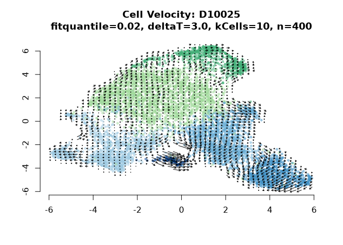

```
## delta projections ... sqrt knn ... transition probs ... done
## calculating arrows ... done
## grid estimates ... grid.sd= 0.1749596  min.arrow.size= 0.003499192  max.grid.arrow.length= 0.03866626  done
## Saved:  ../output/figure_extended/velocyto//velocyto.D10025.qs2
```

```r
run_velocyto_from_precomputed(
    data=data_yap,
    rvel_path=rvel_path_S20127,
    outfile_path=outfile_path_S20127,
    outfile_legend=outfile_legend_S20127,
    outfile_obj=outfile_obj_S20127,
    label="S20127_MUT",
    recode_ids=recode_D10025,
    col_map=col_map_D10025,
    level_order=order_D10025
)
```

```
## Precomputed rvel has 2617 cells; 2617 found in Seurat object
```

```
## delta projections ... sqrt knn ... transition probs ... done
## calculating arrows ... done
## grid estimates ... grid.sd= 0.1741368  min.arrow.size= 0.003482735  max.grid.arrow.length= 0.03284935  done
```

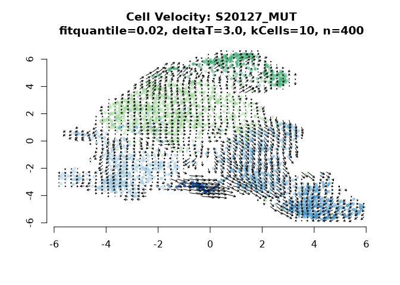

```
## delta projections ... sqrt knn ... transition probs ... done
## calculating arrows ... done
## grid estimates ... grid.sd= 0.1741368  min.arrow.size= 0.003482735  max.grid.arrow.length= 0.03866626  done
## Saved:  ../output/figure_extended/velocyto//velocyto.S20127.qs2
```

```r
run_velocyto_from_precomputed(
    data=data_yap,
    rvel_path=rvel_path_S20128,
    outfile_path=outfile_path_S20128,
    outfile_legend=outfile_legend_S20128,
    outfile_obj=outfile_obj_S20128,
    label="S20128_WT",
    recode_ids=recode_D10025,
    col_map=col_map_D10025,
    level_order=order_D10025
)
```

```
## Precomputed rvel has 3842 cells; 3842 found in Seurat object
```

```
## delta projections ... sqrt knn ... transition probs ... done
## calculating arrows ... done
## grid estimates ... grid.sd= 0.1727817  min.arrow.size= 0.003455633  max.grid.arrow.length= 0.03284935  done
```

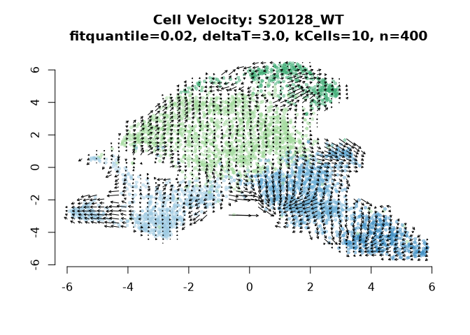

```
## delta projections ... sqrt knn ... transition probs ... done
## calculating arrows ... done
## grid estimates ... grid.sd= 0.1727817  min.arrow.size= 0.003455633  max.grid.arrow.length= 0.03866626  done
## Saved:  ../output/figure_extended/velocyto//velocyto.S20128.qs2
```

## 1.8 Dev utility: shared UMAP axis stamp

Source: `create_template_umap_axis.R`. Draws a small standalone arrow-axis PDF (“UMAP_1” / “UMAP_2”) for compositing onto the stripped (axis-free) UMAP panels above in Illustrator. **Path fix vs source:** the original wrote to `"../Saki/Revision_analysis/queue_plots/mini_axis.pdf"` - `Saki` doesn’t exist as a directory (the real ones are `Saki_data` and `saki_new`), so this never actually wrote anywhere useful. Retargeted to this document’s own output dir below.

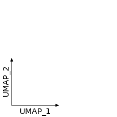

```r
library(grid)

axis_outfile <- paste0(outfile_dir, "mini_axis.pdf")

draw_axis_stamp <- function() {
    grid.newpage()
    grid.lines(c(0.1, 0.5), c(0.1, 0.1),
               arrow=arrow(type="closed", length=unit(0.05, "inches"), angle=20),
               gp=gpar(lwd=1, fill="black"))
    grid.lines(c(0.1, 0.1), c(0.1, 0.5),
               arrow=arrow(type="closed", length=unit(0.05, "inches"), angle=20),
               gp=gpar(lwd=1, fill="black"))
    grid.text("UMAP_1", x=0.3, y=0.05, gp=gpar(cex=0.8))
    grid.text("UMAP_2", x=0.05, y=0.3, rot=90, gp=gpar(cex=0.8))
}

# draw once for the knitted document, once more into the PDF device for the file
draw_axis_stamp()
```

```r
pdf(axis_outfile, width=2, height=2)
draw_axis_stamp()
dev.off()
```

## 1.9 UNUSED - exon vs intron velocyto comparison (QC reference only)

Paths in the source script are **not portable** and will not run as-is from this repo:

- `input_seurat` was originally an absolute path into a lab file server, naming both an internal directory structure and a specific colleague - redacted below and replaced with the same relative convention used everywhere else in this migration.
- `input_loom_exon` / `input_loom_intron` use `"../results/..."`, a convention not used anywhere else in this migration and whose target directory isn’t part of either `Saki_data` or this repo as inspected. Left uncorrected since fixing them would require guessing at infrastructure this migration has no visibility into.

```r
libraries <- c(
    "velocyto.R",
    "pagoda2",
    "qs2",
    "Seurat",
    "SeuratWrappers",
    "ggplot2"
)

load_packages <- function(packages) {
    suppressPackageStartupMessages({
        cat(paste("Loading", packages, sep=" "), sep="\n")
        invisible(sapply(
            packages, library, character.only = TRUE, quietly = TRUE
            ))
    })
}
invisible(Sys.setenv(OPENBLAS_NUM_THREADS="1"))
load_packages(libraries)

# suppress OpenBLAS threading warning
Sys.setenv(OPENBLAS_NUM_THREADS = "1")

# load data
input_seurat <- "../../Saki_data/paper/D10025_yap1_dataset_Level_03_annotated.qs2"
myData_original <- qs_read(input_seurat)

colnames(myData_original@meta.data)

input_loom_exon <- "../results/Dataset_10025_Yap_scRNAseq.20240603.exon.loom"
input_loom_intron <- "../results/Dataset_10025_Yap_scRNAseq.20260311.intron.loom"
ldat_exon <- ReadVelocity(input_loom_exon)
ldat_intron <- ReadVelocity(input_loom_intron)

# paths
project.name <- "Dataset_10025_Yap_exon_intron_velocyto_compare"
out.dir <- "../results/velocyto_compare/"
dir.create(out.dir, recursive=T, showWarnings=F)
group.by <- "L3_celltype"

# plot parameters
alpha <- 0.5
cex <- 0.7
arrow.scale <- 2
show.grid.flow <- TRUE
min.grid.cell.mass <- 1
grid.n <- 50
arrow.lwd <- 1
cell.border.alpha <- 0
n.cores <- 4

Level_03_seurat_cluster_predicted_phenotype_order_cols <- c(
    "#a1d99b",
    "#41ae76",
    "#9ecae1",
    "#6baed6",
    "#4292c6",
    "#2171b5",
    "#084594"
)
names(Level_03_seurat_cluster_predicted_phenotype_order_cols) <- c(
    "Specified_LEC_01",
    "Specified_LEC_02",
    "VEC_01",
    "VEC_02",
    "VEC_03",
    "VEC_04",
    "VEC_05"
)

detect_sample_prefixes <- function(loom_cellnames, n_samples) {
    prefixes <- unique(sub(":.*", "", loom_cellnames))
    if (length(prefixes) != n_samples) {
        warning(sprintf("Expected %d samples but found %d prefixes: %s",
                        n_samples, length(prefixes), paste(prefixes, collapse=", ")))
    }
    return(sort(prefixes))  # sort so sample 1 < sample 2
}

ldats <- list(exon=ldat_exon, intron=ldat_intron)

for (ldat_name in names(ldats)) {
    cat(sprintf("\n===== Processing: %s =====\n", ldat_name))
    list_velocities <- list()
    ldat <- ldats[[ldat_name]]

    # -- cell name matching --
    loom_cellnames <- colnames(ldat$spliced)
    sample_names <- detect_sample_prefixes(loom_cellnames, n_samples = 2)
    cat("Detected prefixes:", paste(sample_names, collapse=", "), "\n")

    for (i in 1:length(sample_names)) {
        current_name <- sprintf("%s:(.*)x", sample_names[i])
        loom_cellnames <- gsub(current_name, sprintf("\\1-1_%i", i), loom_cellnames)
    }

    # -- subset Seurat to cells present in loom --
    n_missing <- sum(!colnames(myData_original) %in% loom_cellnames)
    if (n_missing > 0) {
        cat(sprintf("Note: %d / %d Seurat cells missing from loom, subsetting\n",
                    n_missing, ncol(myData_original)))
    }
    myData_sub <- myData_original[, colnames(myData_original) %in% loom_cellnames]
    cat(sprintf("Proceeding with %d cells\n", ncol(myData_sub)))

    # -- subset loom assays to matched cells --
    list_all_assays_filtered <- lapply(names(x=ldat), function(name){
        assay <- ldat[[name]]
        colnames(assay) <- loom_cellnames
        assay <- assay[, colnames(myData_sub)]  # use myData_sub
    })
    names(list_all_assays_filtered) <- names(x=ldat)

    emat <- list_all_assays_filtered$spliced
    nmat <- list_all_assays_filtered$unspliced

    # -- embeddings from subsetted object --
    emb <- Embeddings(myData_sub, reduction="umap")
    cell.dist <- as.dist(1 - armaCor(t(emb)))

    # -- histograms --
    outfile.plot <- sprintf("%s/%s_histogram_spliced.pdf", out.dir, ldat_name)
    pdf(outfile.plot)
    hist(log10(rowSums(emat)+1), col='wheat',
         xlab='log10[ number of reads + 1]',
         main='Spliced: number of reads per gene')
    dev.off()

    outfile.plot <- sprintf("%s/%s_histogram_unspliced.pdf", out.dir, ldat_name)
    pdf(outfile.plot)
    hist(log10(rowSums(nmat)+1), col='wheat',
         xlab='log10[ number of reads + 1]',
         main='Unspliced: number of reads per gene')
    dev.off()

    # -- UMAP colors from subsetted object --
    gg <- UMAPPlot(myData_sub, group.by=group.by,
                   cols=Level_03_seurat_cluster_predicted_phenotype_order_cols) +
        theme_void() + theme(legend.position="none", plot.title=element_blank())
    colors <- as.list(ggplot_build(gg)$data[[1]]$colour)
    names(colors) <- rownames(emb)

    # -- gene filtering --
    cell_identity <- myData_sub$L3_celltype

    emat_filtered <- filter.genes.by.cluster.expression(
        emat, cell_identity, min.max.cluster.average=0.1
    )
    cat(sprintf("emat_filtered: %d genes x %d cells\n", nrow(emat_filtered), ncol(emat_filtered)))

    nmat_filtered <- filter.genes.by.cluster.expression(
        nmat, cell_identity, min.max.cluster.average=0.05
    )
    cat(sprintf("nmat_filtered: %d genes x %d cells\n", nrow(nmat_filtered), ncol(nmat_filtered)))

    # -- velocity estimation --
    fit.quantile <- 0.02
    deltaT <- 3
    kCells <- 10

    rvel <- gene.relative.velocity.estimates(
        emat_filtered,
        nmat_filtered,
        deltaT=deltaT,
        kCells=kCells,
        cell.dist=cell.dist,
        fit.quantile=fit.quantile,
        n.cores=n.cores
    )

    list_velocities[[ldat_name]] <- rvel

    # -- velocity plot --
    n <- 400
    outfile.plot <- sprintf(
        "%s/%s_UMAP_velocyto_filtered_fq%0.2f_dT%0.1f_kCells%i_n%i.pdf",
        out.dir, ldat_name, fit.quantile, deltaT, kCells, n
    )
    pdf(outfile.plot)
    show.velocity.on.embedding.cor(
        emb,
        rvel,
        n=n,
        scale='sqrt',
        cell.colors=ac(colors, alpha=alpha),
        cex=cex,
        arrow.scale=arrow.scale,
        show.grid.flow=show.grid.flow,
        min.grid.cell.mass=min.grid.cell.mass,
        grid.n=grid.n,
        arrow.lwd=arrow.lwd,
        do.par=F,
        cell.border.alpha=cell.border.alpha,
        n.cores=n.cores,
        main=sprintf(
            "Cell Velocity: %s filtered\nfitquantile=%.2f, deltaT=%.1f, kCells=%i, n=%i",
            ldat_name, fit.quantile, deltaT, kCells, n
        )
    )
    dev.off()

    # -- save (one RDS per loom, only its own result) --
    export_name <- sprintf("%s/%s_velocyto_filtered_all_params.RDS", out.dir, ldat_name)
    saveRDS(list_velocities, export_name)
    cat(sprintf("Saved: %s\n", export_name))
}
```

## 1.10 For developers

Sample run command:

```bash
Rscript -e "
rmarkdown::render(
  'velocyto_analysis.Rmd',
  output_file = './velocyto_analysis.html'
)
"
```